# Da matriz de contagens à biologia: um olhar estatístico

Minicurso da 70ª RBras · Encontro 2 de 2

Benilton S Carvalho (IMECC/UNICAMP)

## Como será o encontro de hoje

PARTE 1 · 8 MINOs dadosContagens, esparsidade e o modelo de amostragem

PARTE 2 · 12 MINQualidadeQuais células são observações válidas?

PARTE 3 · 10 MINNormalizaçãoMédia, variância e genes informativos

PARTE 4 · 15 MINPCA e UMAPRedução de dimensão e o que se pode ler num gráfico

PARTE 5 · 12 MINAgrupamentoGrafos, modularidade e a escolha da resolução

PARTE 6 · 15 MINMarcadores e DETestes por gene, *double dipping* e pseudorreplicação

PARTE 7 · 10 MINAnálise funcionalDa lista de genes ao processo biológico

MATERIALPara depoisNotebooks, slides completos e pontos de resgate

## O que muda em relação ao plano original

- Não executaremos células hoje: os resultados mostrados vêm da execução completa dos notebooks.
- O foco é a **decisão estatística** em cada etapa: o que está sendo estimado, testado ou escolhido.
- Os notebooks dos encontros 1 e 2 continuam completos para estudo, com os pontos de resgate CP0 a CP5.
- Os slides originais dos dois encontros trazem o passo a passo do código.

**Pergunta que guia o dia:** em cada etapa, qual é a unidade amostral, qual é o modelo e qual escolha do analista muda o resultado?

# Os dados

PARTE 1

≈ 8 min · notebooks: encontro 1, blocos B01 e B02a

## Por que medir uma célula de cada vez?

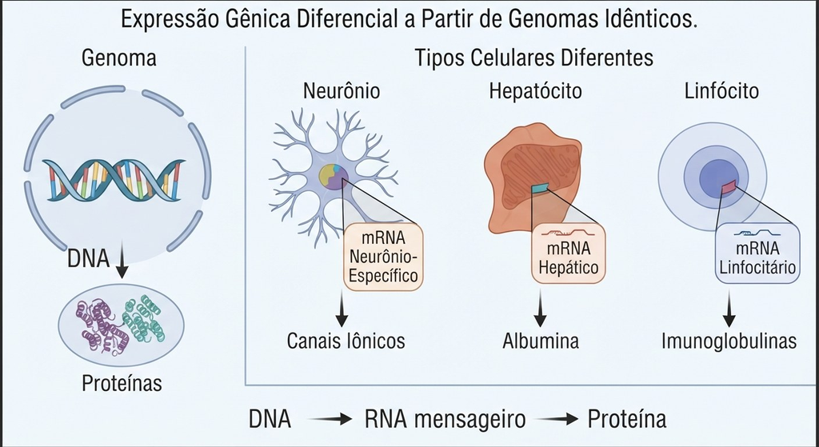

Todas as células têm o mesmo genoma. O tipo celular é definido por **quais genes estão sendo expressos** e em que quantidade.

## A amostra: lavado broncoalveolar na COVID-19

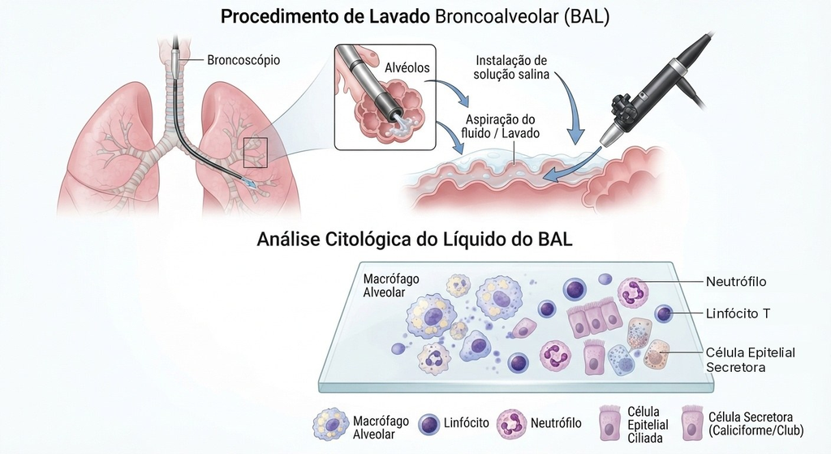

Amostra C141 do GSE145926 (Liao et al., *Nature Medicine*, 2020). Esperamos macrófagos, linfócitos e células epiteliais das vias aéreas.

## Como a matriz é gerada

[figure not shown]

Cada gotícula recebe uma célula e uma esfera com código de barras. Cada molécula de mRNA recebe um UMI. Contamos UMIs, não leituras.

## A matriz de contagens como objeto estatístico

- $Y_{gc}$: número de moléculas (UMIs) do gene $g$ na célula $c$.
- Na C141: **33.539 genes × 6.249 células**.
- Cerca de **94% das entradas são zero**: a matriz densa ocupa 1,6 GB; a esparsa, 159 MB.
- Zeros são, em grande parte, amostragem: poucas moléculas capturadas por célula.
- Precisamos de um modelo para essas contagens: ele orienta a normalização, a seleção de genes e os testes.

## Um modelo de trabalho para um gene $g$

$$Y_{gc} \sim \text{NB}\big(\mu_{gc},\ \phi_g\big), \qquad \mu_{gc} = s_c\,\lambda_g$$

$$\operatorname{Var}(Y_{gc}) = \mu_{gc} + \phi_g\,\mu_{gc}^2$$

| Símbolo | O que representa |
| --- | --- |
| $Y_{gc}$ | contagem de UMIs do gene $g$ na célula $c$ |
| $\mu_{gc}$ | contagem esperada do gene $g$ na célula $c$ |
| $s_c$ | fator de tamanho da célula (técnico): profundidade e eficiência de captura |
| $\lambda_g$ | abundância relativa do gene $g$: a quantidade de interesse biológico |
| $\phi_g$ | sobredispersão: variação além da Poisson ($\phi_g = 0$ recupera a Poisson) |

**Normalizar** = estimar o parâmetro de incômodo $s_c$ e removê-lo, para comparar $\lambda_g$ entre células.

## Qual é a unidade amostral?

- Hoje, a **célula** é a observação: agrupamento e marcadores descrevem populações dentro de **um indivíduo**.
- Células do mesmo indivíduo **não são independentes** para comparar condições (doente × controle).
- Para comparar condições, a unidade é o **indivíduo**. Voltamos a isso na Parte 6.

Desenho hierárquico: indivíduo → amostra → célula → molécula. Cada nível tem sua variância.

# Controle de qualidade

PARTE 2

≈ 12 min · notebook: encontro 1, blocos B02a e B02b

## O que pode dar errado numa gotícula

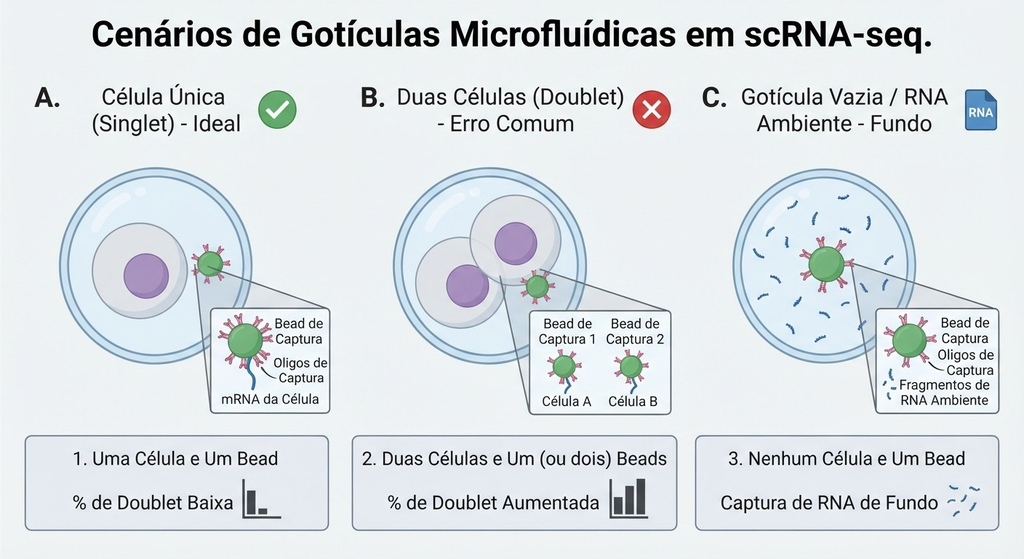

Gotícula com duas células (*doublet*) parece um tipo celular novo. Gotícula sem célula traz só RNA ambiente.

## Por que a % mitocondrial denuncia células danificadas

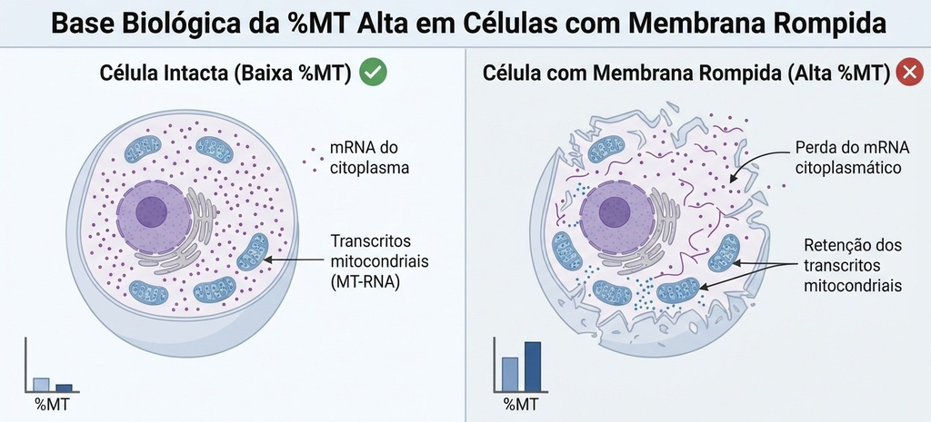

Com a membrana rompida, o mRNA do citoplasma escapa. Os transcritos dentro das mitocôndrias ficam. A fração de genes `MT-` cresce.

## Três métricas, uma pergunta

| Métrica | O que mede | Valor suspeito indica |
| --- | --- | --- |
| `nCount_RNA` | total de UMIs da célula | baixo: gotícula vazia; alto: *doublet* |
| `nFeature_RNA` | genes com ao menos 1 UMI | baixo: célula pobre; alto: *doublet* |
| `percent.mt` | % de UMIs de genes `MT-` | alto: célula danificada |

Do ponto de vista estatístico, QC é **detecção de observações atípicas** num espaço de três variáveis fortemente correlacionadas. Não existe rótulo verdadeiro: o limiar é uma decisão.

## A distribuição de `nCount_RNA` é bimodal

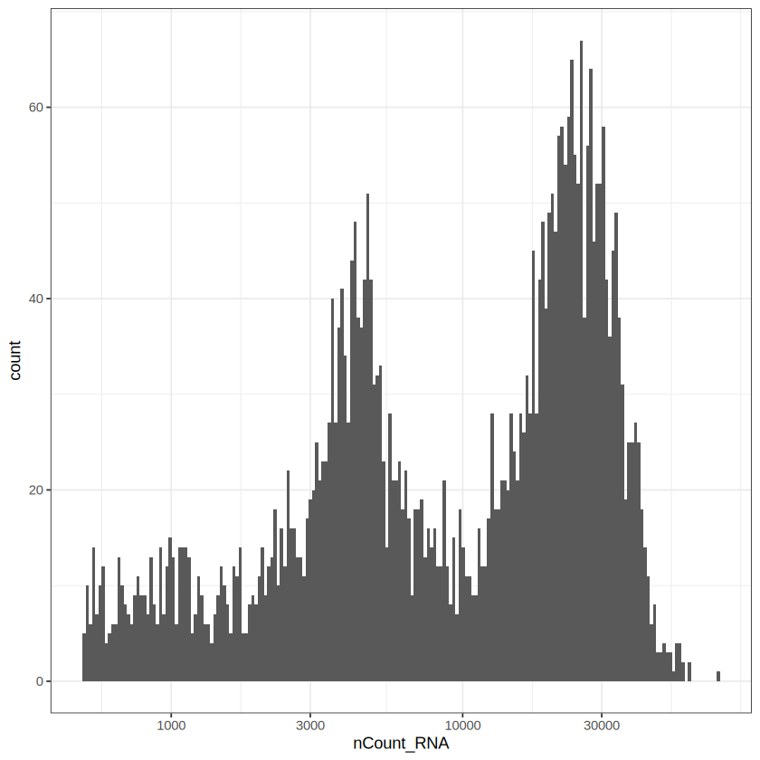

Escala log. Mediana de 11.768 UMIs por célula; mínimo de 502. A moda à esquerda concentra células com pouco RNA.

Saída da célula 58 do Módulo 04 · `geom_histogram()`

## A % mitocondrial tem cauda longa

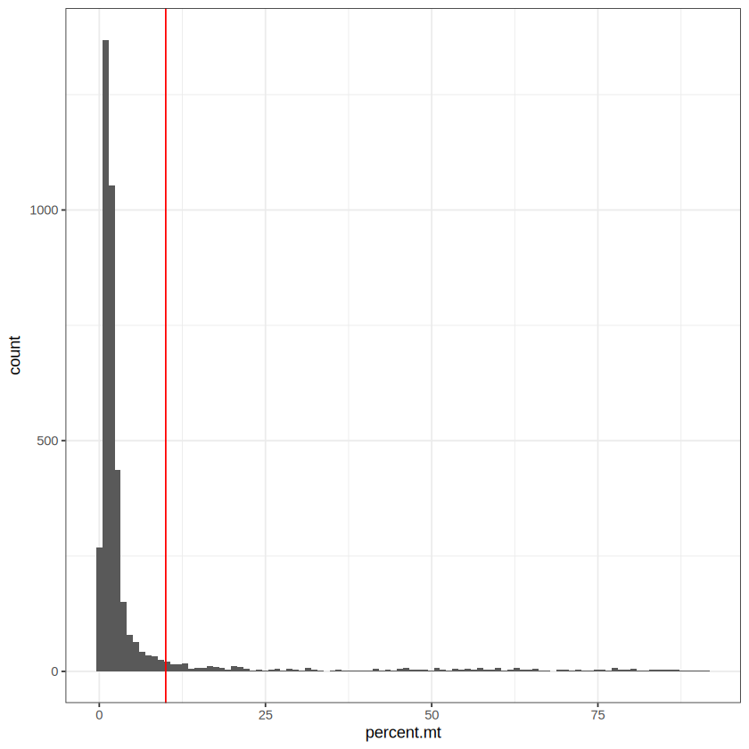

Mediana de 1,6%, média de 5,7%, máximo de 91%. A média é puxada pela cauda: use estatísticas robustas.

Saída da célula 63 do Módulo 04 · linha vermelha em 10%

## As métricas devem ser vistas em conjunto

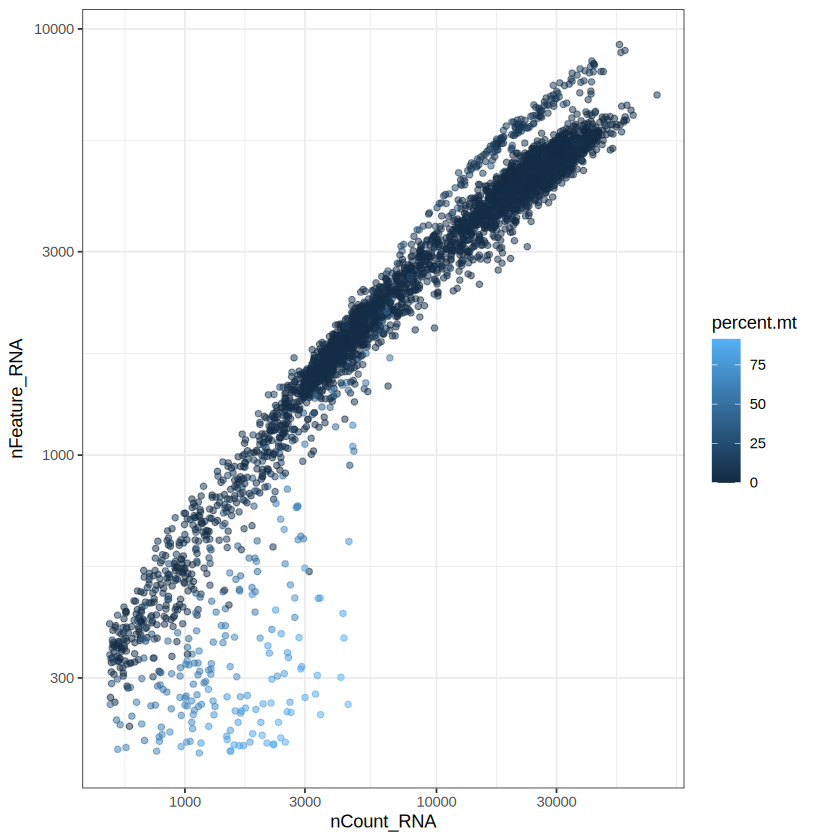

Células com poucos genes e % mitocondrial alta formam uma nuvem separada, abaixo da relação principal.

Saída da célula 68 do Módulo 04 · eixos em escala log

## Limiar fixo ou limiar adaptativo?

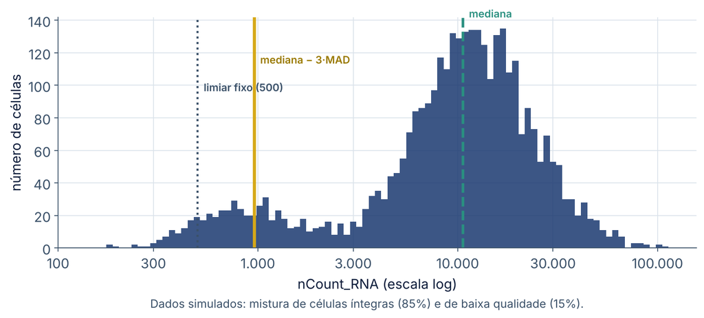

Regra robusta, em escala log:

$$\text{MAD} = \text{1,4826} \cdot \operatorname{med}_c \big| x_c - \operatorname{med}(x) \big|$$

remover $c$ se $x_c < \operatorname{med}(x) - 3\,\text{MAD}$

- O limiar se adapta à amostra e ao tecido.
- Alternativa: modelo de mistura com um componente “baixa qualidade”.

## A decisão tomada no notebook

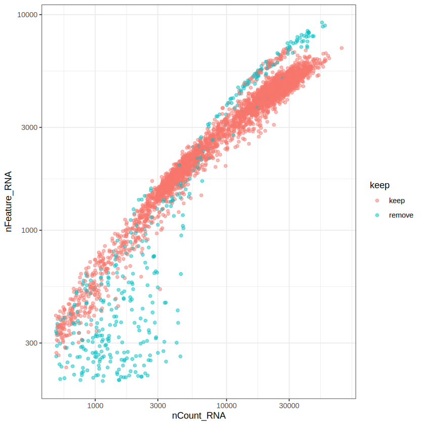

Regra: `nCount_RNA > 500` e `nFeature_RNA < 7000` e `percent.mt < 10`. Em ciano, as células removidas.

Saída da célula 72 do Módulo 04

## Quantas células sobraram

6.249gotículas com célula  
(saída do Cell Ranger)

→

4.233≥ 200 genes por célula  
genes em ≥ 3 células

→

3.949284 *doublets* removidos  
(scDblFinder)

→

3.541limiares de QC  
20.271 genes

**scDblFinder** cria *doublets* artificiais somando pares de células ao acaso. Um classificador (*gradient boosting*) aprende a distinguir os artificiais dos reais e dá a cada célula um escore de “ser *doublet*”.

QC é seleção dependente dos dados. Tipos celulares pequenos ou com muito RNA mitocondrial podem ser removidos junto com o ruído.

# Normalização e genes variáveis

PARTE 3

≈ 10 min · notebook: encontro 1, blocos B03 e B05

## Dois problemas a resolver

1. **Profundidade diferente:** uma célula com o dobro de UMIs não tem o dobro de RNA de interesse. Precisamos remover $s_c$.
2. **Variância depende da média:** genes muito expressos dominariam qualquer distância euclidiana.

**LogNormalize** (Seurat, padrão):

$$x_{gc} = \log\left(1 + 10^4 \cdot \frac{y_{gc}}{\sum_{g'} y_{g'c}}\right)$$

Estimador de $s_c$: o total de UMIs da célula. Pseudocontagem 1 para o log de zero.

## A relação média × variância

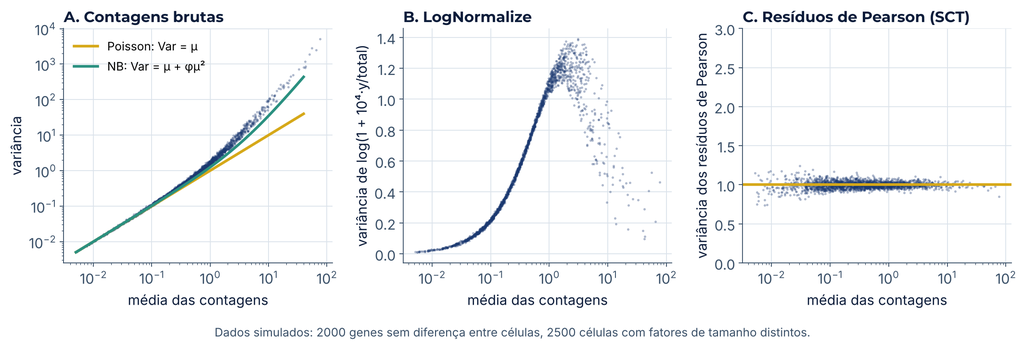

A: Poisson subestima a variância; a binomial negativa acompanha. B: o log reduz mas não elimina a dependência. C: resíduos de Pearson têm variância ≈ 1.

## SCTransform: um GLM por gene

**Profundidade** da célula: $n_c = \sum_g y_{gc}$, o total de UMIs (a métrica `nCount_RNA`).

Para cada gene, regressão binomial negativa com $\ln n_c$ como *offset*:

$$\ln \mu_{gc} = \beta_{0g} + \ln n_c \quad\Longleftrightarrow\quad \mu_{gc} = n_c\, e^{\beta_{0g}}$$

Modelo de trabalho da Parte 1 com $s_c = n_c$, $\lambda_g = e^{\beta_{0g}}$. Expressão “normalizada” = **resíduo de Pearson**:

$$r_{gc} = \frac{y_{gc} - \hat\mu_{gc}}{\sqrt{\hat\mu_{gc} + \hat\phi_g\,\hat\mu_{gc}^2}}$$

- $\phi_g$ é **regularizado** entre genes de média parecida (*shrinkage*): cada gene tem pouca informação.
- Versão 1: inclinação de $\ln n_c$ estimada por gene. Versão 2 (notebook): fixada em 1 (*offset*).

Hafemeister & Satija, 2019 · Choudhary & Satija, 2022 (*Genome Biology*) · célula 107

## Por que selecionar genes variáveis?

- Dos 20.271 genes, a maioria **não distingue** tipos celulares: varia só por amostragem.
- Um gene que separa tipos tem variância **acima** do esperado pela média. Com $T$ = tipo celular:

$$\operatorname{Var}(Y) = \underbrace{\mathbb{E}[\operatorname{Var}(Y \mid T)]}_{\text{ruído}} + \underbrace{\operatorname{Var}(\mathbb{E}[Y \mid T])}_{\text{sinal}}$$

- Os HVG definem o **espaço de variáveis** da PCA. Dele saem o grafo de vizinhos, os grupos e o UMAP.
- Genes só com ruído **diluem as distâncias** entre células e escondem a estrutura.
- Os testes de marcadores e de DE usam **todos** os genes, não só os HVG.

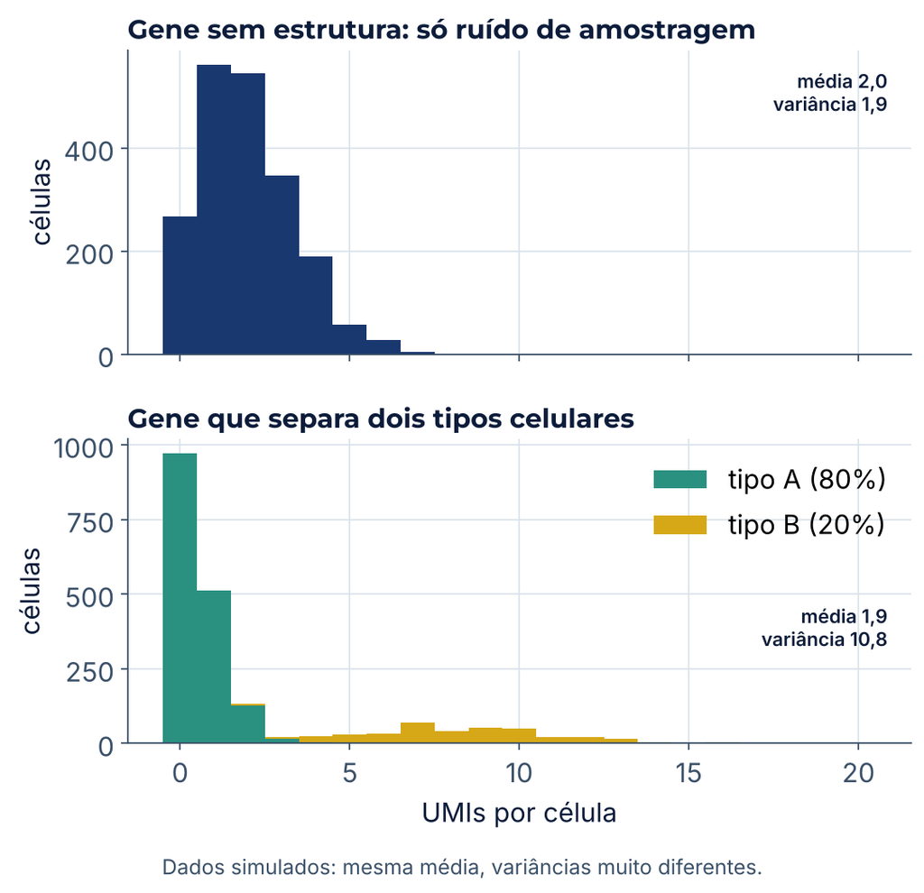

## Como o Seurat escolhe os genes variáveis

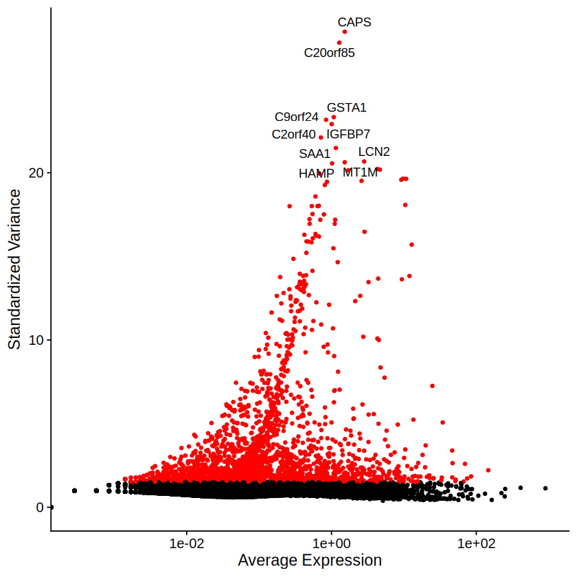

Método `vst` do Seurat:

1. Ajusta *loess* de $\log \hat\sigma_g$ em $\log \bar y_g$.
2. Padroniza: $z_{gc} = (y_{gc} - \bar y_g)/\hat\sigma_g^{\text{loess}}$, truncado em $\sqrt{N}$.
3. Ordena genes pela variância de $z$ e fica com os **2.000** maiores.

É seleção de variáveis **não supervisionada**: busca genes com variância acima do esperado pela média.

Saída da célula 85 do Módulo 04 · `VariableFeaturePlot()`

# PCA e UMAP

PARTE 4

≈ 15 min · notebook: encontro 1, blocos B04 e B06

## PCA: a velha conhecida

Matriz $Z$ de 3.541 células × 2.000 genes, centrada e escalada por gene:

$$Z = U D V^\top, \qquad \text{escores} = UD, \qquad \text{cargas} = V$$

- O Seurat calcula os **50 primeiros** componentes (SVD truncada, `irlba`).
- Por que reduzir antes de tudo? Ruído de amostragem se espalha em todas as direções; a estrutura biológica se concentra em poucas.
- Os passos seguintes (vizinhos, agrupamento, UMAP) usam **os escores dos PCs**, não os genes.

## Quanto cada componente explica

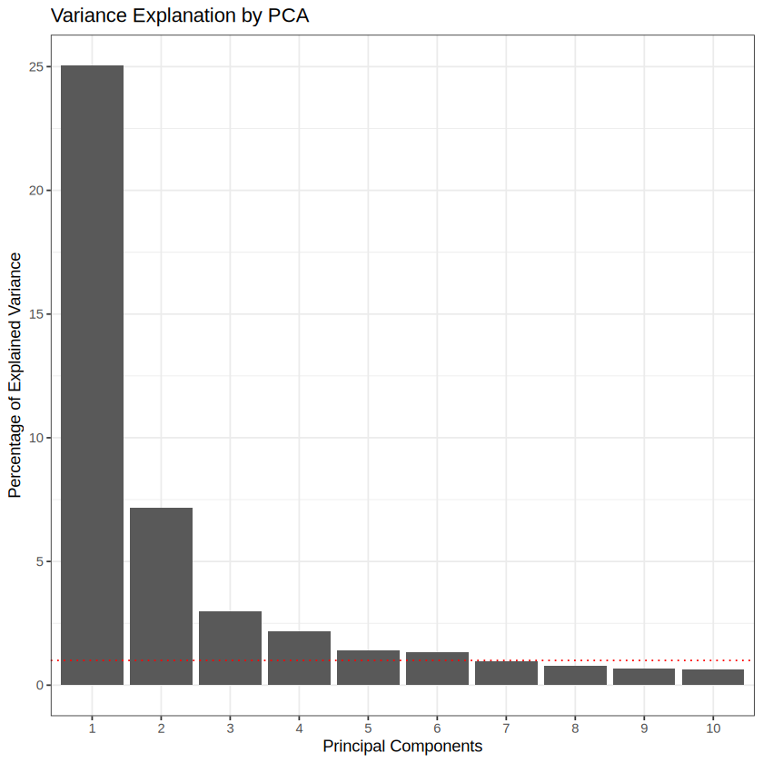

PC1 explica 25,0% da variância dos 2.000 genes; PC2, 7,2%. Os 20 primeiros somam 47,1%.

Saída da célula 96 do Módulo 04

## Quantos componentes usar?

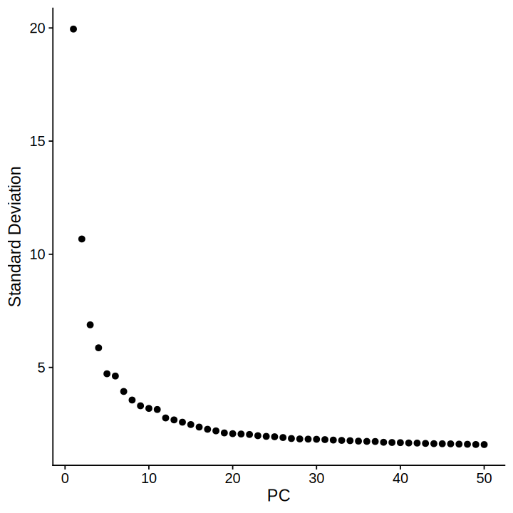

Não há cotovelo nítido. O notebook usa 15 PCs no UMAP e 20 PCs no agrupamento: é uma escolha do analista.

Saída da célula 124 do Módulo 04 · `ElbowPlot(ndims = 50)`

## O que o PC1 separa?

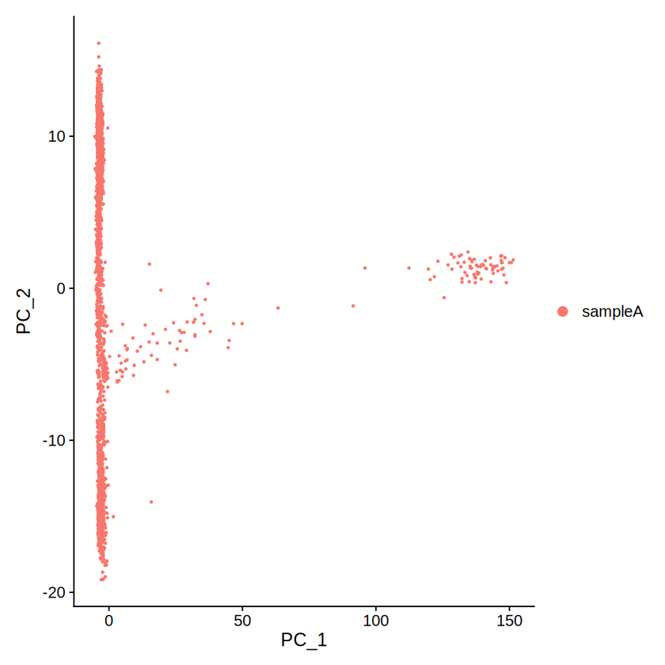

Um pequeno grupo de células se afasta ao longo do PC1. As cargas positivas são genes de cílio: `LRRIQ1`, `EFCAB1`, `CFAP43`, `DNAH10`.

Saída da célula 94 do Módulo 04 · `DimPlot(reduction = "pca")`

## Leitura biológica das cargas

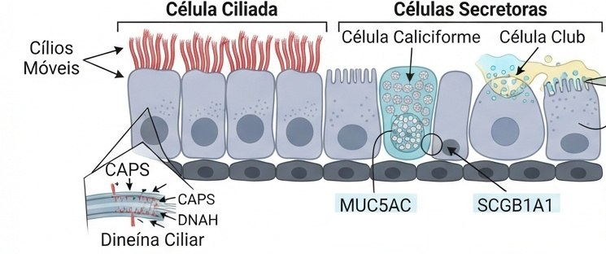

PC1 positivo: células epiteliais **ciliadas** das vias aéreas. PC1 negativo: células imunes (`CD52`, `CD68`, `C1QA`, `LYZ`).

## UMAP em uma página

1. Constrói um grafo de $k$ vizinhos no espaço dos PCs, com pesos $w_{ij} = \exp\{-(d_{ij} - \rho_i)/\sigma_i\}$.
2. Posiciona os pontos no plano com afinidade $q_{ij} = (1 + a\,\lVert y_i - y_j \rVert^{2b})^{-1}$.
3. Minimiza a entropia cruzada entre os dois grafos:

$$\sum_{i,j} \Big[ w_{ij} \log \frac{w_{ij}}{q_{ij}} + (1 - w_{ij}) \log \frac{1 - w_{ij}}{1 - q_{ij}} \Big]$$

O UMAP preserva **quem é vizinho de quem**. Distâncias entre grupos, tamanhos de grupos e densidades no gráfico **não têm interpretação quantitativa**.

McInnes, Healy & Melville, 2018 · Chari & Pachter, *PLoS Comput Biol*, 2023

## O UMAP distorce tamanhos e distâncias

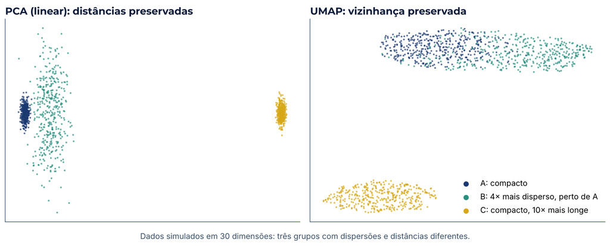

## O resultado depende do número de PCs

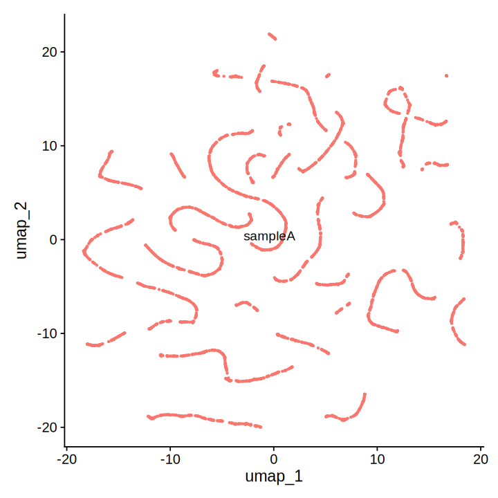

2 PCs

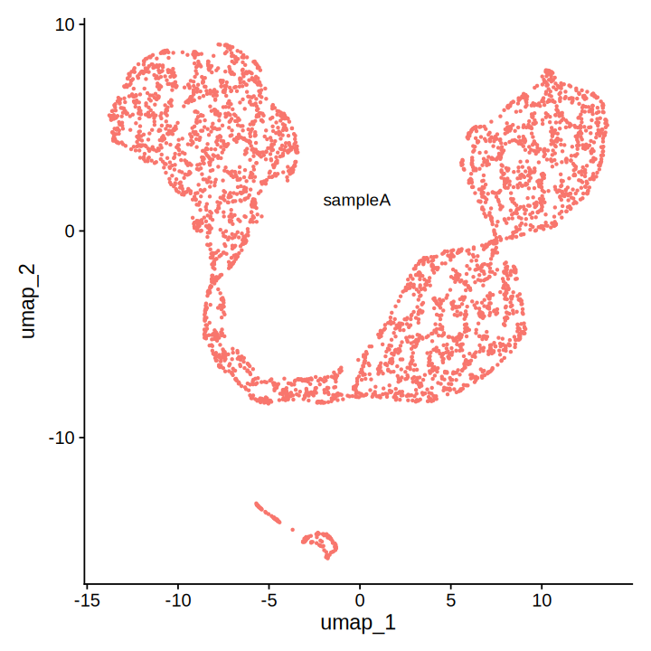

3 PCs

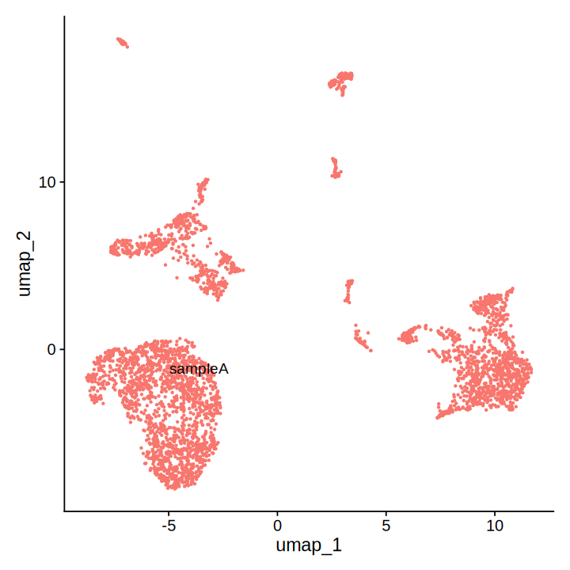

15 PCs

Com 2 ou 3 PCs surgem “estruturas” que são artefato. Com 15 PCs aparecem grupos compactos e separados.

Saídas das células 125, 126 e 127 do Módulo 04 · `RunUMAP(dims = ...)`

## Diagnóstico: a estrutura é técnica ou biológica?

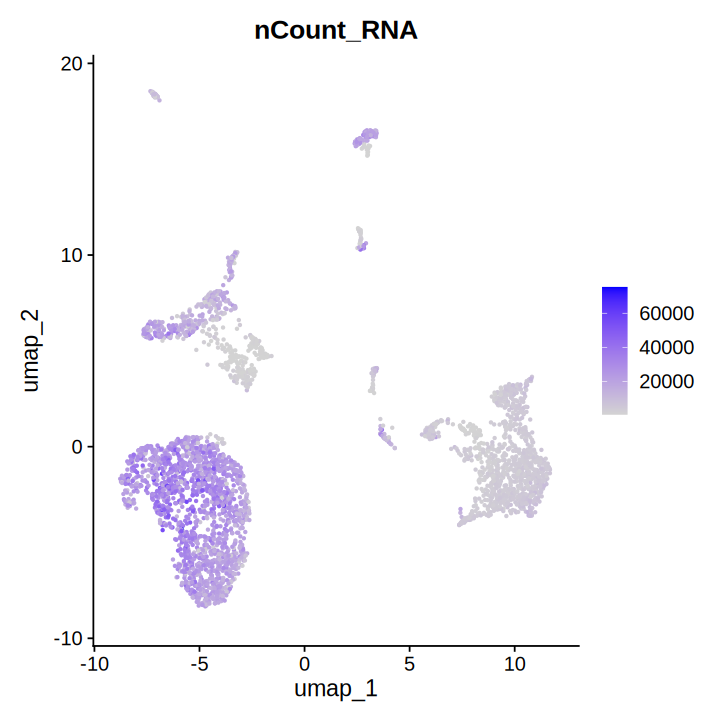

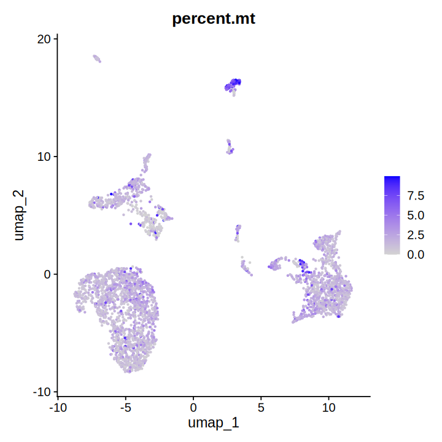

Pinte o UMAP com as covariáveis técnicas. Se um grupo coincide com profundidade ou % MT, desconfie dele antes de nomeá-lo.

Saídas das células 129 e 128 do Módulo 04 · `FeaturePlot()`

# Agrupamento

PARTE 5

≈ 12 min · notebook: encontro 2, bloco B07

## Por que não k-médias?

- Os tipos celulares têm tamanhos muito diferentes: na C141, 71 células ciliadas num total de 3.541.
- Os grupos não são esféricos: há gradientes de diferenciação e de ativação.
- A solução padrão em célula única é **agrupar um grafo de vizinhança**, não os pontos no espaço.

`FindNeighbors(dims = 1:20)`: grafo kNN nos 20 primeiros PCs, ponderado pela sobreposição de vizinhanças (SNN):

$$w_{ij} = \frac{|N_k(i) \cap N_k(j)|}{|N_k(i) \cup N_k(j)|} \quad \text{(índice de Jaccard)}$$

## Do espaço dos PCs ao grafo SNN

[figure not shown]

Na C141, o grafo tem 3.541 nós e 117.724 arestas.

## Louvain: maximizar a modularidade

$$Q(\gamma) = \frac{1}{2m} \sum_{i,j} \Big[ A_{ij} - \gamma \frac{k_i k_j}{2m} \Big] \, \mathbb{1}(c_i = c_j)$$

- $A_{ij}$: peso da aresta; $k_i$: grau do nó; $m$: soma dos pesos.
- O termo $k_i k_j / 2m$ é o número esperado de arestas num **modelo nulo** com os mesmos graus.
- $\gamma$ é o parâmetro de **resolução**: maior $\gamma$, mais grupos.
- Louvain (ou Leiden) é uma heurística gulosa: rodamos várias partidas aleatórias e ficamos com o maior $Q$.

O número de grupos **não é estimado**: ele é consequência de $\gamma$, de $k$ e do número de PCs.

## Resolução: a mesma amostra, três respostas

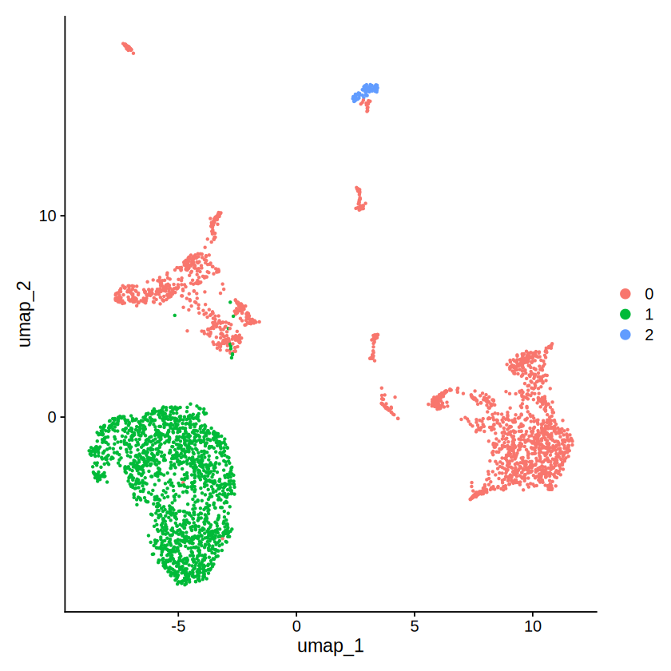

γ = 0,01: **3 grupos**

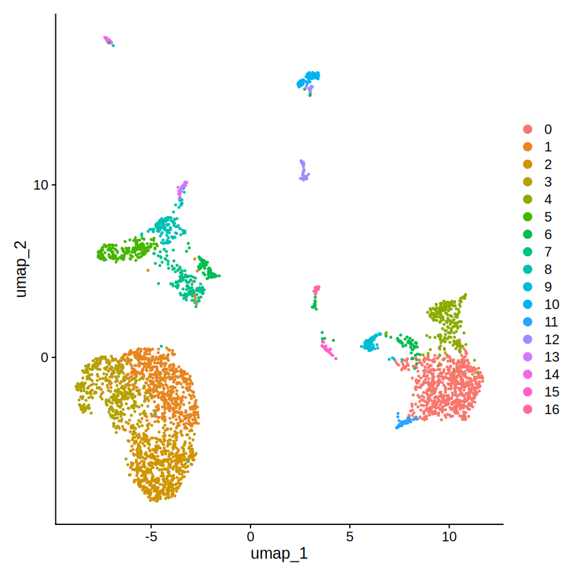

γ = 0,8 (padrão): **17 grupos**

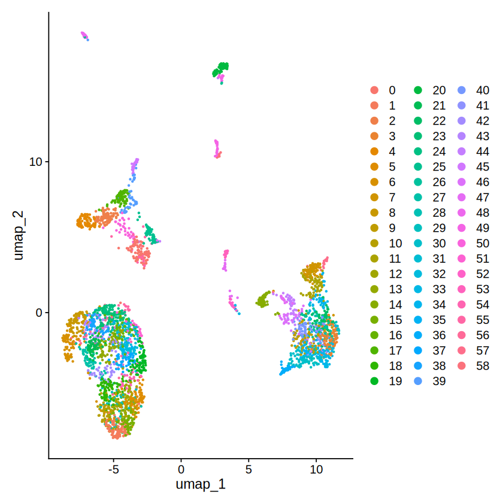

γ = 10: **59 grupos**

Saídas das células 147, 144 e 149 do Módulo 04 · `FindClusters(resolution = ...)`

## Grupos são níveis de uma hierarquia biológica

- Tipos celulares formam uma **árvore de linhagens** (hematopoese): mieloide e linfoide, depois tipos, depois estados.
- **Resolução baixa** recupera os níveis de cima da árvore.
- **Resolução alta** recupera os níveis terminais: subtipos e estados de ativação.
- Na C141, γ = 0,01 separou 3 grupos; γ = 0,2 separou 11, já com T, NK, mieloides e epiteliais.

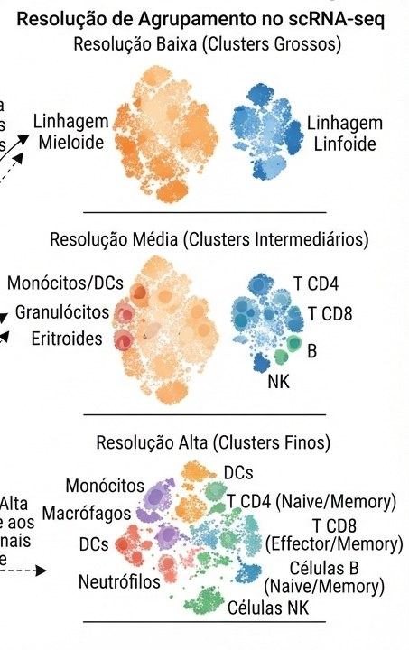

## Como escolher a resolução

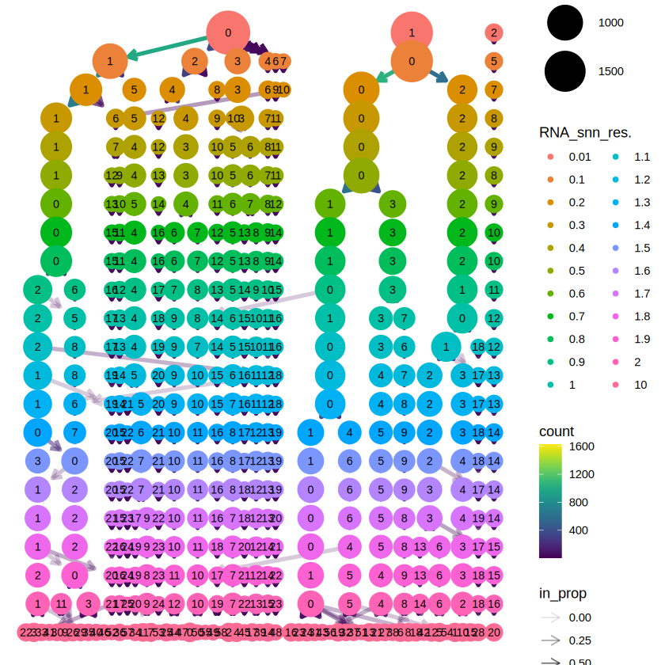

*clustree*: cada linha é uma resolução. Grupos que se mantêm ao longo de várias linhas são estáveis. Setas cruzando indicam partições instáveis.

Saída da célula 154 do Módulo 04 · γ de 0,01 a 2 e γ = 10

## Critérios que um estatístico reconhece

- **Silhueta** média por resolução: coesão interna contra separação do vizinho mais próximo.
- **Estabilidade**: reamostrar células (*bootstrap*) ou genes e medir a concordância (índice de Rand ajustado).
- **Comparação com outro método**: hierárquico de Ward nos mesmos PCs.
- **Critério biológico**: o grupo tem marcadores coerentes? Essa é a pergunta da Parte 6.

Não há “k verdadeiro”. A resolução deve responder à pergunta científica: linhagens, tipos ou estados.

# Marcadores e expressão diferencial

PARTE 6

≈ 15 min · notebook: encontro 2, blocos B08 a B11

## Marcador × gene diferencialmente expresso

- **Gene marcador:** distingue um grupo de todos os outros. Serve para **nomear** o grupo.
- **Expressão diferencial (DE):** difere entre dois grupos específicos. Serve para **comparar** estados.
- No Seurat, as duas perguntas usam o mesmo teste por gene, com contrastes diferentes.

[figure not shown]

## O teste por gene no Seurat

Para cada gene, `FindMarkers()` compara $x_{gc}$ (log-normalizado) entre os grupos com o **teste de Wilcoxon-Mann-Whitney** (via `presto`).

| Coluna | Significado |
| --- | --- |
| `avg_log2FC` | $\log_2$ da razão das médias em escala linear (com pseudocontagem) |
| `pct.1`, `pct.2` | fração de células com $y_{gc} > 0$ em cada grupo |
| `p_val` | valor-p do Wilcoxon |
| `p_val_adj` | **Bonferroni**: `p_val` × 20.271 genes |

Filtros prévios (`min.pct = 0.25`, `logfc.threshold = 0.25`) reduzem o número de testes, mas são escolhidos olhando os mesmos dados.

## Os grupos ganham nome pelos marcadores

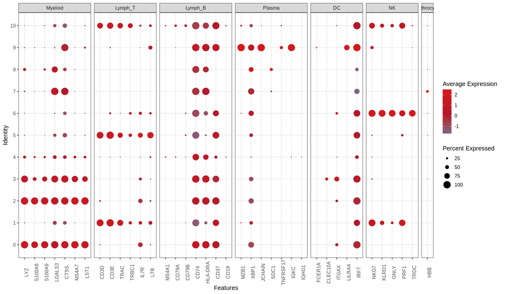

Linfócitos T nos grupos 1, 5 e 10; NK no 6; mieloides em 0, 2 e 3. `LILRA4` e `IRF7` no grupo 9 indicam DC plasmocitoides.

Saída da célula 191 do Módulo 04 · `DotPlot()`: tamanho = `pct`, cor = média escalada

## Dois tipos de macrófago: grupos 0 e 2

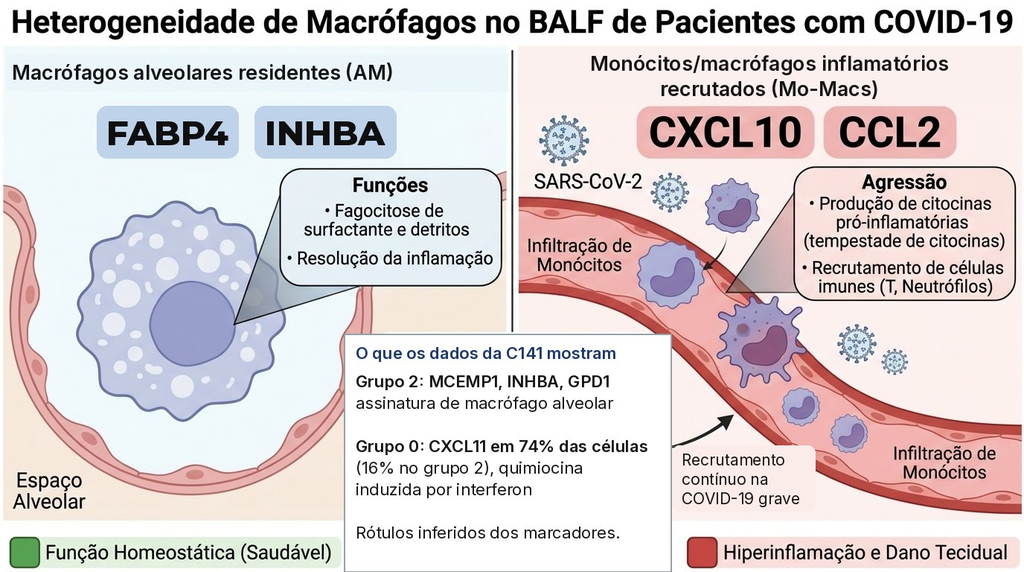

Os nomes vêm dos marcadores. A anotação automática (SingleR) faz isso de forma sistemática: correlação de Spearman com perfis de referência purificados.

## Linfócitos T e NK: grupos 1, 5 e 6

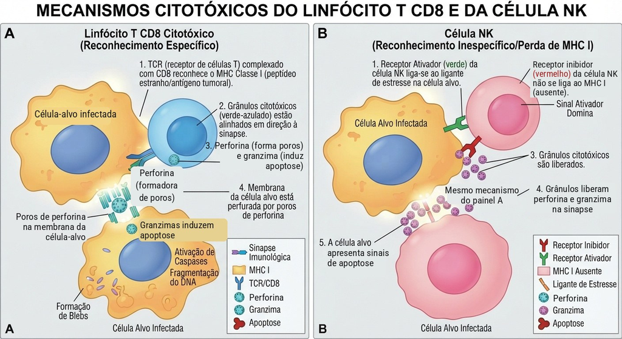

Genes de T e NK nos dados: `CD3E`, `CD8A`, `GZMA`, `PRF1`, `NKG7`. Perforina e granzima são as armas citotóxicas.

## Um contraste de DE: grupo 2 × grupo 0

| Gene | log2FC | pct.1 | pct.2 |
| --- | --- | --- | --- |
| `MCEMP1` | 3,2 | 0,99 | 0,47 |
| `HP` | 2,8 | 0,89 | 0,44 |
| `STAC` | 2,6 | 0,82 | 0,33 |
| `CXCL11` | −5,1 | 0,16 | 0,74 |
| `MARCKS` | −4,2 | 0,11 | 0,71 |

`MCEMP1`: p = 10⁻²⁰⁸

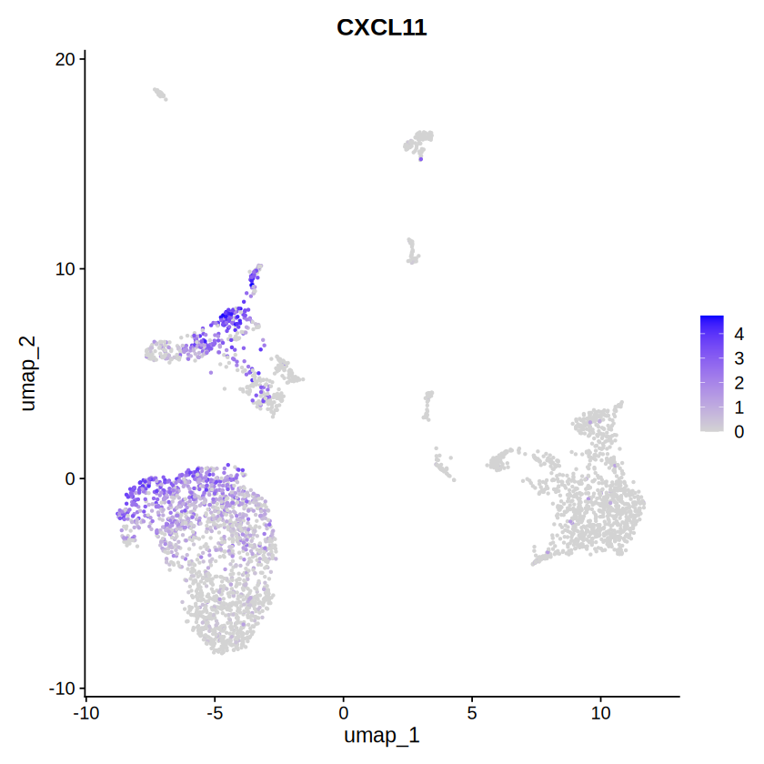

Saídas das células 172 e 174 do Módulo 04 · `FindMarkers(ident.1 = 2, ident.2 = 0)`

## Problema 1: *double dipping*

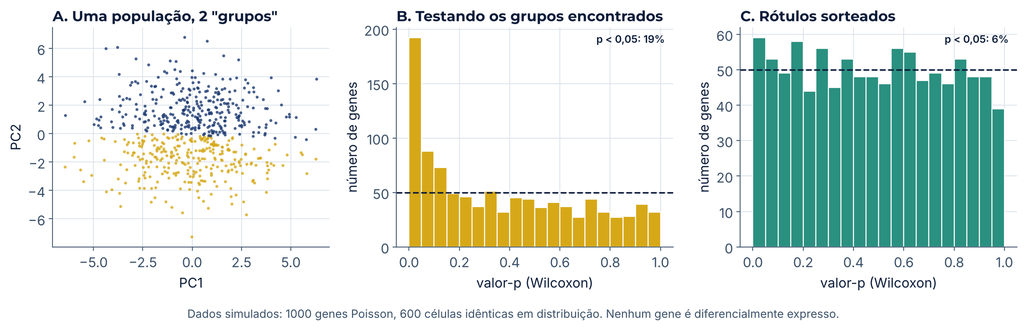

Os grupos foram **definidos** pelos mesmos dados usados no teste. Mesmo sem nenhuma diferença real, a distribuição dos valores-p deixa de ser uniforme.